# Import all the relevant libraries

```python
import numpy as np
from sklearn.linear_model import LinearRegression
import pandas as pd
import matplotlib.pyplot as plt
import seaborn as sns
from sklearn import preprocessing
from sklearn.model_selection import train_test_split
from sklearn import metrics
from sklearn.linear_model import LogisticRegression
from sklearn.metrics import f1_score
from sklearn.metrics import precision_score
from sklearn.metrics import recall_score
import matplotlib as mpl
import matplotlib.pyplot as plt
from sklearn import preprocessing
from sklearn.preprocessing import StandardScaler
from sklearn.metrics import accuracy_score
from sklearn.neighbors import KNeighborsClassifier
from sklearn.naive_bayes import GaussianNB
from sklearn.naive_bayes import BernoulliNB
from sklearn.metrics import classification_report, confusion_matrix, accuracy_score
from scipy.stats import chi2_contingency
import scipy
from scipy.stats import chi2
from scipy.stats import zscore
from statsmodels.stats.outliers_influence import variance_inflation_factor
from imblearn.over_sampling import SMOTE
from collections import Counter
from sklearn.metrics import roc_curve
from sklearn.metrics import roc_auc_score
import warnings
warnings.filterwarnings("ignore")
```

# Part1

CONTEXT: Medical research university X is undergoing a deep research on patients with certain conditions. University has an internal AI team. Due to confidentiality the patient’s details and the conditions are masked by the client by providing different datasets to the AI team for developing a AIML model which can predict the condition of the patient depending on the received test results.

DATA DESCRIPTION:The data consists of biomechanics features of the patients according to their current conditions. Each patient is represented in the data set by six biomechanics attributes derived from the shape and orientation of the condition to their body part.

1. P_incidence
2. P_tilt
3. L_angle
4. S_slope
5. P_radius
6. S_degree
7. Class

**1. Import and warehouse data:**

- Import all the given datasets and explore shape and size of each.
- Merge all datasets onto one and explore final shape and size.

```python
#loading the datasets and forming one dataframe
df1=pd.read_csv('Part1 - Normal.csv')
df2=pd.read_csv('Part1 - Type_H.csv')
df3=pd.read_csv('Part1 - Type_S.csv')
data=pd.concat([df1,df2,df3])
```

```python
#Checking the size of each dataframe and final data frame after concatinating all of them together
print('Shape of df1: ', df1.shape)
print('Shape of df2: ', df2.shape)
print('Shape of df3: ', df3.shape)
print('Shape of data (The concatinated dataframe): ', data.shape)
```

```
Shape of df1:  (100, 7)
Shape of df2:  (60, 7)
Shape of df3:  (150, 7)
Shape of data (The concatinated dataframe):  (310, 7)
```

```python
# Checking the data using top 5
data.head()
```

|  | P_incidence | P_tilt | L_angle | S_slope | P_radius | S_Degree | Class |
| --- | --- | --- | --- | --- | --- | --- | --- |
| 0 | 38.505273 | 16.964297 | 35.112814 | 21.540976 | 127.632875 | 7.986683 | Normal |
| 1 | 54.920858 | 18.968430 | 51.601455 | 35.952428 | 125.846646 | 2.001642 | Normal |
| 2 | 44.362490 | 8.945435 | 46.902096 | 35.417055 | 129.220682 | 4.994195 | Normal |
| 3 | 48.318931 | 17.452121 | 48.000000 | 30.866809 | 128.980308 | -0.910941 | Normal |
| 4 | 45.701789 | 10.659859 | 42.577846 | 35.041929 | 130.178314 | -3.388910 | Normal |

```python
#Checking the data using below 5
data.tail()
```

|  | P_incidence | P_tilt | L_angle | S_slope | P_radius | S_Degree | Class |
| --- | --- | --- | --- | --- | --- | --- | --- |
| 145 | 80.111572 | 33.942432 | 85.101608 | 46.169139 | 125.593624 | 100.292107 | Type_S |
| 146 | 95.480229 | 46.550053 | 59.000000 | 48.930176 | 96.683903 | 77.283072 | Type_S |
| 147 | 74.094731 | 18.823727 | 76.032156 | 55.271004 | 128.405731 | 73.388216 | Type_S |
| 148 | 87.679087 | 20.365613 | 93.822416 | 67.313473 | 120.944829 | 76.730629 | Type_S |
| 149 | 48.259920 | 16.417462 | 36.329137 | 31.842457 | 94.882336 | 28.343799 | Type_S |

**2. Data cleansing:**

- Explore and if required correct the datatypes of each attribute
- Explore for null values in the attributes and if required drop or impute values.

Analysing the dataset and making it compatible for the process:

```python
#checking the datatypes and other information about the loaded dataset using info function
data.info()
```

```
<class 'pandas.core.frame.DataFrame'>
Int64Index: 310 entries, 0 to 149
Data columns (total 7 columns):
 #   Column       Non-Null Count  Dtype
---  ------       --------------  -----
 0   P_incidence  310 non-null    float64
 1   P_tilt       310 non-null    float64
 2   L_angle      310 non-null    float64
 3   S_slope      310 non-null    float64
 4   P_radius     310 non-null    float64
 5   S_Degree     310 non-null    float64
 6   Class        310 non-null    object
dtypes: float64(6), object(1)
memory usage: 19.4+ KB
```

```python
#Checking for the presence of any null values in all the given columns of the dataset
data.isnull().any()
```

```
P_incidence    False
P_tilt         False
L_angle        False
S_slope        False
P_radius       False
S_Degree       False
Class          False
dtype: bool
```

```python
#Checking for nay duplicates in the dataset
data.duplicated().values.any()
```

```
False
```

```python
#Getting the 5 point summary of the data
data.describe().transpose()
```

|  | count | mean | std | min | 25% | 50% | 75% | max |
| --- | --- | --- | --- | --- | --- | --- | --- | --- |
| P_incidence | 310.0 | 60.496653 | 17.236520 | 26.147921 | 46.430294 | 58.691038 | 72.877696 | 129.834041 |
| P_tilt | 310.0 | 17.542822 | 10.008330 | -6.554948 | 10.667069 | 16.357689 | 22.120395 | 49.431864 |
| L_angle | 310.0 | 51.930930 | 18.554064 | 14.000000 | 37.000000 | 49.562398 | 63.000000 | 125.742385 |
| S_slope | 310.0 | 42.953831 | 13.423102 | 13.366931 | 33.347122 | 42.404912 | 52.695888 | 121.429566 |
| P_radius | 310.0 | 117.920655 | 13.317377 | 70.082575 | 110.709196 | 118.268178 | 125.467674 | 163.071041 |
| S_Degree | 310.0 | 26.296694 | 37.559027 | -11.058179 | 1.603727 | 11.767934 | 41.287352 | 418.543082 |

- There is a huge gap between 75% and max value of S_Degree column indicating the presence of outliers
- Also the std deviation of the S_Degree column is comparitively on a higher end

```python
# In the given dataset Class column is the most suited target variable.
# Hence checking the values present in the Class column
data.Class.unique()
```

```
array(['Normal', 'Nrmal', 'Type_H', 'type_h', 'Type_S', 'tp_s'],
      dtype=object)
```

```python
# The Class column needs the value to be corrected as the data is not given correctly
#Replacing the 'Nrmal','type_h','tp_s' to 'Normal','Type_H','Type_S' respectively
data['Class'].replace(['Nrmal','type_h','tp_s'],['Normal','Type_H','Type_S'], inplace=True)
```

```python
print('Checking the 5 point summary for the individual Class: ')
print('\n')
print('\n')
print('Normal Class:-->')
print(data[data.Class=='Normal'].describe())
print('\n')
print('Type_H Class:-->')
print(data[data.Class=='Type_H'].describe())
print('\n')
print('Type_S Class:-->')
print(data[data.Class=='Type_S'].describe())
```

```
Checking the 5 point summary for the individual Class:




Normal Class:-->
       P_incidence      P_tilt     L_angle     S_slope    P_radius    S_Degree
count   100.000000  100.000000  100.000000  100.000000  100.000000  100.000000
mean     51.685244   12.821414   43.542605   38.863830  123.890834    2.186572
std      12.368161    6.778503   12.361388    9.624004    9.014246    6.307483
min      30.741938   -5.845994   19.071075   17.386972  100.501192  -11.058179
25%      42.817849    8.799951   35.000000   32.340487  118.182659   -1.511360
50%      50.123115   13.482435   42.638923   37.059694  123.874328    1.152710
75%      61.470097   16.785953   51.602346   44.608788  129.040401    4.968807
max      89.834676   29.894119   90.563461   67.195460  147.894637   31.172767


Type_H Class:-->
       P_incidence     P_tilt    L_angle    S_slope    P_radius   S_Degree
count    60.000000  60.000000  60.000000  60.000000   60.000000  60.000000
mean     47.638407  17.398795  35.463524  30.239612  116.474968   2.480251
std      10.697131   7.016708   9.767795   7.555388    9.355720   5.531177
min      26.147921   3.144669  14.000000  13.366931   84.241415 -10.675871
25%      41.018099  12.874329  29.038069  25.215275  112.280320  -0.910819
50%      46.416169  16.949285  35.164873  30.000659  116.696146   2.542441
75%      53.922329  22.002980  42.011563  34.962103  122.042999   6.059666
max      74.433593  41.557331  62.275275  46.613539  137.540613  15.779697


Type_S Class:-->
       P_incidence      P_tilt     L_angle     S_slope    P_radius    S_Degree
count   150.000000  150.000000  150.000000  150.000000  150.000000  150.000000
mean     71.514224   20.748038   64.110108   50.766186  114.518810   51.896687
std      15.109337   11.506169   16.397068   12.318813   15.579995   40.108030
min      37.903910   -6.554948   24.710274   19.290046   70.082575    1.010041
25%      60.658136   13.461149   52.000000   43.166815  104.706761   30.393271
50%      72.149306   19.309548   62.555200   50.751695  114.842400   42.372509
75%      81.075893   29.229680   76.990924   56.675435  123.337307   61.894425
max     129.834041   49.431864  125.742385  121.429566  163.071041  418.543082
```

- The std of Class Type_S seems to be little off
- Type_S also shows the presence of outliers

```python
# Since the Class column is present as an object, converting it to the category type
data['Class'] = data.Class.astype('category')
```

```python
# Checking the datatype after change
data.dtypes
```

```
P_incidence     float64
P_tilt          float64
L_angle         float64
S_slope         float64
P_radius        float64
S_Degree        float64
Class          category
dtype: object
```

```python
#checking the count each Class present in the dataset
data["Class"].value_counts(normalize=True)
```

```
Type_S    0.483871
Normal    0.322581
Type_H    0.193548
Name: Class, dtype: float64
```

- The target column doesnot seem to be rightly balanced as Type_H class has relatively smaller nos present.
- This might require balancing of target for better model prediction (to be performed later)

```python
# Checking the data grouped by Class
data.groupby(["Class"]).count()
```

| Class | P_incidence | P_tilt | L_angle | S_slope | P_radius | S_Degree |
| --- | --- | --- | --- | --- | --- | --- |
| Normal | 100 | 100 | 100 | 100 | 100 | 100 |
| Type_H | 60 | 60 | 60 | 60 | 60 | 60 |
| Type_S | 150 | 150 | 150 | 150 | 150 | 150 |

```python
#Checking for any null data
data.isnull().any().any()
```

```
False
```

```python
# Checking the dimension
data.ndim
```

```
2
```

**3. Data analysis & visualisation:**

- Perform detailed statistical analysis on the data.
- Perform a detailed univariate, bivariate and multivariate analysis with appropriate detailed comments after each analysis.

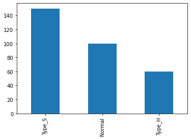

```python
# Graph for the value counts of each Class
pd.value_counts(data["Class"]).plot(kind="bar")
```

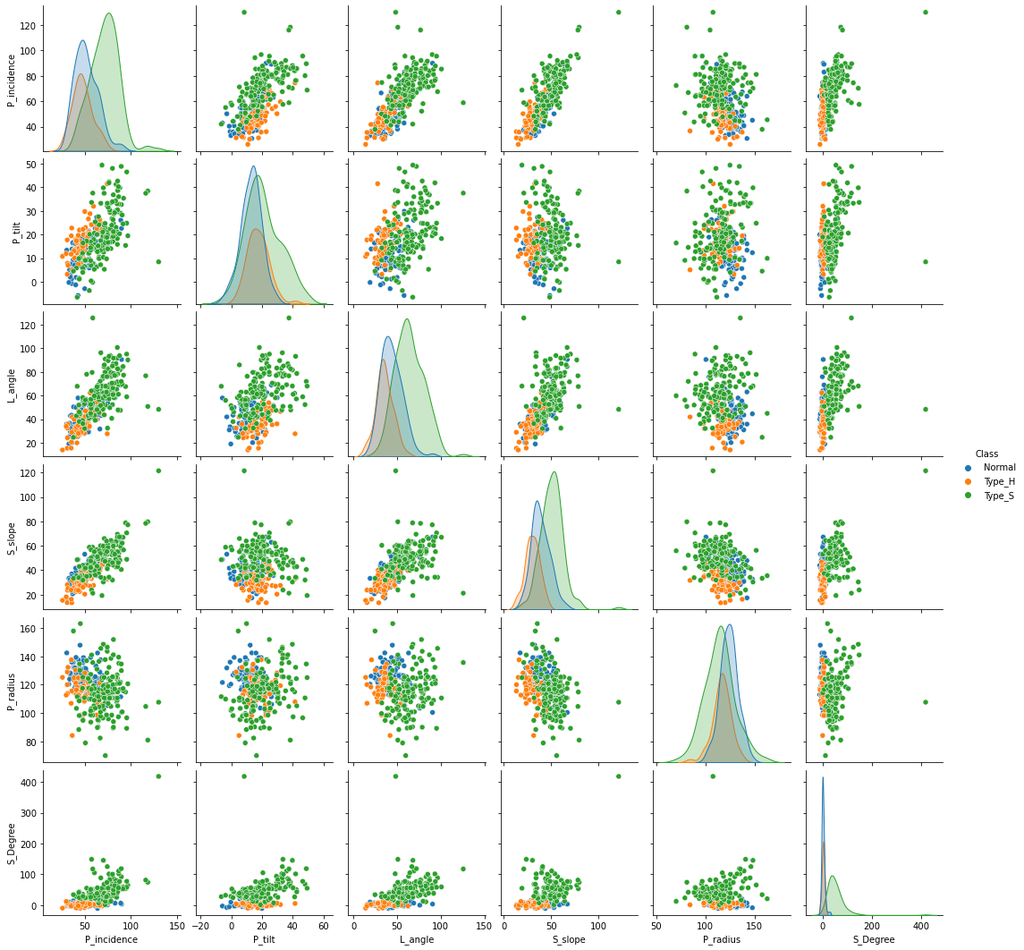

```python
# Ploting pairplot for the Class column
sns.pairplot(data, hue='Class')
plt.show()
```

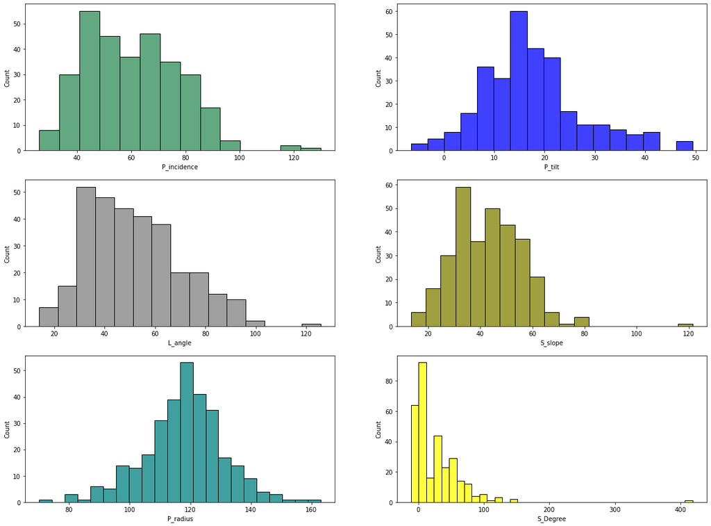

```python
# Plotting the distribution graph for all the columns of the given dataset
fig, ax =plt.subplots(3,2, figsize=(20,15))


sns.histplot( x='P_incidence', color="seagreen", data=data, ax=ax[0][0])
sns.histplot( x='P_tilt', color="blue", data=data, ax=ax[0][1])
sns.histplot( x='L_angle', color="grey",data=data, ax=ax[1][0])
sns.histplot( x='S_slope', color="olive", data=data, ax=ax[1][1])
sns.histplot( x='P_radius', color="teal", data=data, ax=ax[2][0])
sns.histplot( x='S_Degree', color="yellow", data=data, ax=ax[2][1])
```

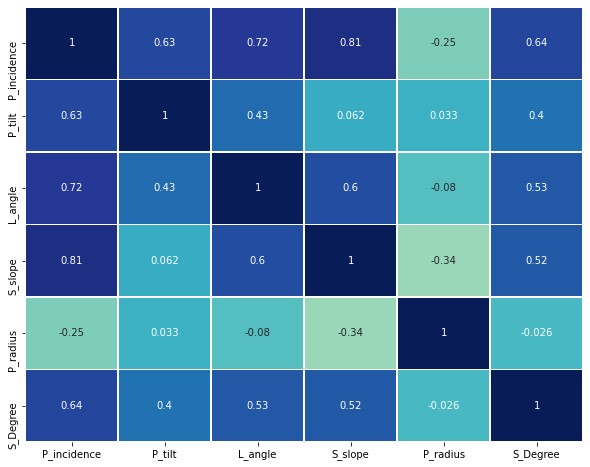

```python
# Plotting the correlation heat map to indicate the correlation between different variables in the dataset with each other
plt.figure(figsize=(10,8))
sns.heatmap(data.corr(),
            annot=True,
            linewidths=.5,
            center=0,
            cbar=False,
            cmap="YlGnBu")
plt.show()
```

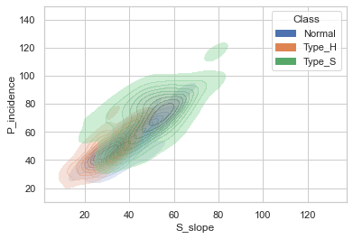

```python
# Plotting the density curve forr the class with to P_incidence and P_slope to view the spread
sns.set(style="whitegrid")
sns.kdeplot(data=data,x="S_slope", y="P_incidence", hue="Class", fill=True, common_norm=False, alpha=0.4)
```

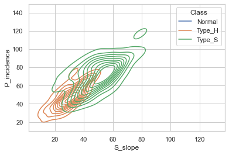

```python
# plotting the graph without Normal class to see the spread of Class type_s and type_h wrt to each other
sns.kdeplot(data=data[data.Class != 'Normal'],x="S_slope", y="P_incidence", hue='Class')
```

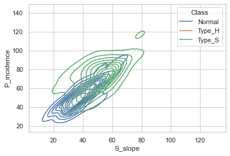

```python
# plotting graph without Type_h class to see the spread of Class type_s and normal wrt to each other
sns.kdeplot(data=data[data.Class != 'Type_H'],x="S_slope", y="P_incidence", hue='Class')
```

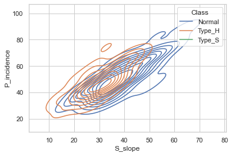

```python
# plotting graph without type_s class to see the spread of Class type_h and normal wrt to each other
sns.kdeplot(data=data[data.Class != 'Type_S'],x="S_slope", y="P_incidence", hue='Class')
```

From the correlation and kdeplots above, it can be infered that

- The highest correlation is between S_slope and P_incidence
- Lowest correlation is between S_Degree and P_radius
- The Normal class seems to be overlapping the type_h and Type_S
- When Type_h and type_s are plotted after a certain threshold the value can be classified as type S

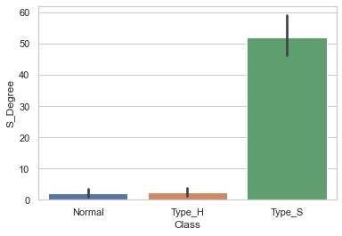

```python
# Plotting the barplot
sns.barplot(x='Class', y='S_Degree', data=data);
```

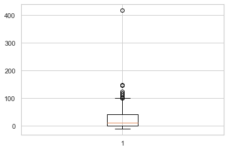

```
upper_fence :  100.2921068 , lower_fence :  -11.05817866
No of outliers present which is greater than the upper fence:  10
```

```python
#plotting a box plot curve to check the presence of outliers
boxplt=plt.boxplot(data["S_Degree"])
plt.show()
#finding the upper and lower fence
lower_fence=boxplt['caps'][0].get_data()[1][1]
upper_fence=boxplt['caps'][1].get_data()[1][1]
print('upper_fence : ',upper_fence, ', lower_fence : ',lower_fence)
#Check number of outliers greater than upper fence.
n_outliers=len(data[data['S_Degree']>upper_fence])
print('No of outliers present which is greater than the upper fence: ',n_outliers)
```

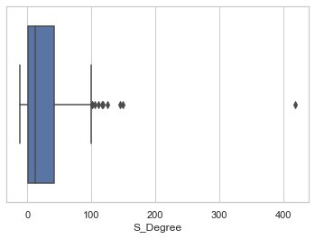

```python
# Plotting a boxplot again having better visualization using seaborn
sns.boxplot(data["S_Degree"])
```

*Inference*

- There is good amount of difference between the max outlier and other outliers after upper fence also. Removing the max outlier to make the data bit better.

```python
df_rem=data.nlargest(1, ['S_Degree'])
df_rem
```

|  | P_incidence | P_tilt | L_angle | S_slope | P_radius | S_Degree | Class |
| --- | --- | --- | --- | --- | --- | --- | --- |
| 55 | 129.834041 | 8.404475 | 48.384057 | 121.429566 | 107.690466 | 418.543082 | Type_S |

```python
# droping greatest outlier from S_degree from the dataset
data.drop(df_rem.index, axis=0,inplace=True)
```

```python
# Top 5 values after dropping the top 5 outliers
data.nlargest(5, ['S_Degree'])
```

|  | P_incidence | P_tilt | L_angle | S_slope | P_radius | S_Degree | Class |
| --- | --- | --- | --- | --- | --- | --- | --- |
| 35 | 57.522356 | 33.647075 | 50.909858 | 23.875281 | 140.981712 | 148.753711 | Type_S |
| 15 | 70.221452 | 39.822724 | 68.118403 | 30.398728 | 148.525562 | 145.378143 | Type_S |
| 132 | 74.469082 | 33.283157 | 66.942101 | 41.185925 | 146.466001 | 124.984406 | Type_S |
| 81 | 89.504947 | 48.903653 | 72.003423 | 40.601295 | 134.634291 | 118.353370 | Type_S |
| 137 | 58.828379 | 37.577873 | 125.742385 | 21.250506 | 135.629418 | 117.314683 | Type_S |

**4. Data pre-processing:**

- Segregate predictors vs target attributes
- Perform normalisation or scaling if required.
- Check for target balancing. Add your comments.
- Perform train-test split.

```python
sc_X = StandardScaler()
X =  pd.DataFrame(sc_X.fit_transform(data.drop(["Class"],axis = 1),),
        columns=['P_incidence', 'P_tilt', 'L_angle', 'S_slope', 'P_radius','S_Degree'])
y = data.Class
X_train, X_test, y_train, y_test = train_test_split(X, y, test_size=0.2, random_state=1,stratify=y)
```

```python
# Print the shape of the Training dataset
print(X_train.shape)
print(y_train.shape)
```

```
(245, 6)
(245,)
```

```python
# Print the shape of the testing dataset
print(X_test.shape)
print(y_test.shape)
```

```
(62, 6)
(62,)
```

```python
c_train = Counter(y_train)
c_test = Counter(y_test)
print("Count of Each Class in the Training Dataset: ", c_train)
print("Count of Each Class in the Test Dataset: ", c_test)
```

```
Count of Each Class in the Training Dataset:  Counter({'Type_S': 119, 'Normal': 79, 'Type_H': 47})
Count of Each Class in the Test Dataset:  Counter({'Type_S': 30, 'Normal': 20, 'Type_H': 12})
```

This clearly indicates that the target column is imbalanced

```python
#Checking the amount of data in train and test after the split
print("{0:0.2f}% data is in training set".format((len(X_train)/len(data.index)) * 100))
print("{0:0.2f}% data is in test set".format((len(X_test)/len(data.index)) * 100))
```

```
79.80% data is in training set
20.20% data is in test set
```

**5. Model training, testing and tuning:**

- Design and train a KNN classifier.
- Display the classification accuracies for train and test data.
- Display and explain the classification report in detail.
- Automate the task of finding best values of K for KNN.
- Apply all the possible tuning techniques to train the best model for the given data. Select the final best trained model with your comments for selecting this model.

```python
#Since the no. of records after outlier removal is 305, sqrt of 310 nears to 17. So taking K to be 17(+)/(-)7
knn = KNeighborsClassifier(n_neighbors=10)
knn.fit(X_train, y_train)
# predict the response
y_pred = knn.predict(X_test)
```

```python
print('Accuracy of Training Data: ', knn.score(X_train, y_train))
print('Accuracy of Testing Data: ', knn.score(X_test, y_test))
```

```
Accuracy of Training Data:  0.8408163265306122
Accuracy of Testing Data:  0.7741935483870968
```

```python
confusion= confusion_matrix(y_test, y_pred)
print('Confusion Matrix:-->\n')
print(confusion)
print('\n')
print("Classification Report:--> \n", classification_report(y_test, y_pred))
```

```
Confusion Matrix:-->

[[17  2  1]
 [ 7  5  0]
 [ 1  3 26]]


Classification Report:-->
               precision    recall  f1-score   support

      Normal       0.68      0.85      0.76        20
      Type_H       0.50      0.42      0.45        12
      Type_S       0.96      0.87      0.91        30

    accuracy                           0.77        62
   macro avg       0.71      0.71      0.71        62
weighted avg       0.78      0.77      0.77        62
```

The classification report visualizer displays the precision, recall, F1, and support scores for the model

There are four ways to check if the predictions are right or wrong:

- TN / True Negative: the case was negative and predicted negative
- TP / True Positive: the case was positive and predicted positive
- FN / False Negative: the case was positive but predicted negative
- FP / False Positive: the case was negative but predicted positive

The report indicates:

1. Precision — What percent of our predictions were correct? Precision = TP/(TP + FP)
2. Recall — What percent of the positive cases did we catch? Recall = TP/(TP+FN)
3. F1 score — What percent of positive predictions were correct? F1 Score = 2*(Recall* Precision) / (Recall + Precision)
4. Support- Support is the number of actual occurrences of the class in the specified dataset

```python
# creating odd list of K for KNN
myList = list(range(3,25))

# subsetting just the odd ones
neighbors = list(filter(lambda x: x % 2 != 0, myList))
```

```python
# Checking the accuracy of the model for different K values

for k in neighbors:
    NNH = KNeighborsClassifier(n_neighbors = k) #, weights = 'distance' )
    NNH.fit(X_train, y_train)
    y_pred = NNH.predict(X_test)
    print('For K Value: ', k, ' Score/Accuracy on KNN Model For Training Dataset: ', (NNH.score(X_train, y_train))*100)
    print('For K Value: ', k, ' Score/Accuracy on KNN Model For Test Dataset: ', (NNH.score(X_test, y_test))*100)
    print(' ')
```

```
For K Value:  3  Score/Accuracy on KNN Model For Training Dataset:  93.87755102040816
For K Value:  3  Score/Accuracy on KNN Model For Test Dataset:  70.96774193548387

For K Value:  5  Score/Accuracy on KNN Model For Training Dataset:  86.53061224489797
For K Value:  5  Score/Accuracy on KNN Model For Test Dataset:  77.41935483870968

For K Value:  7  Score/Accuracy on KNN Model For Training Dataset:  84.89795918367346
For K Value:  7  Score/Accuracy on KNN Model For Test Dataset:  77.41935483870968

For K Value:  9  Score/Accuracy on KNN Model For Training Dataset:  83.26530612244898
For K Value:  9  Score/Accuracy on KNN Model For Test Dataset:  82.25806451612904

For K Value:  11  Score/Accuracy on KNN Model For Training Dataset:  84.48979591836735
For K Value:  11  Score/Accuracy on KNN Model For Test Dataset:  79.03225806451613

For K Value:  13  Score/Accuracy on KNN Model For Training Dataset:  84.08163265306122
For K Value:  13  Score/Accuracy on KNN Model For Test Dataset:  77.41935483870968

For K Value:  15  Score/Accuracy on KNN Model For Training Dataset:  81.63265306122449
For K Value:  15  Score/Accuracy on KNN Model For Test Dataset:  80.64516129032258

For K Value:  17  Score/Accuracy on KNN Model For Training Dataset:  82.85714285714286
For K Value:  17  Score/Accuracy on KNN Model For Test Dataset:  77.41935483870968

For K Value:  19  Score/Accuracy on KNN Model For Training Dataset:  82.85714285714286
For K Value:  19  Score/Accuracy on KNN Model For Test Dataset:  77.41935483870968

For K Value:  21  Score/Accuracy on KNN Model For Training Dataset:  82.44897959183673
For K Value:  21  Score/Accuracy on KNN Model For Test Dataset:  79.03225806451613

For K Value:  23  Score/Accuracy on KNN Model For Training Dataset:  81.22448979591836
For K Value:  23  Score/Accuracy on KNN Model For Test Dataset:  79.03225806451613
```

```python
# empty list that will hold accuracy scores
ac_scores = []

# perform accuracy metrics for values from 10, 13, ...24
for k in neighbors:
    knn = KNeighborsClassifier(n_neighbors=k)
    knn.fit(X_train, y_train)
    # predict the response
    y_pred = knn.predict(X_test)
    # evaluate accuracy
    scores = accuracy_score(y_test, y_pred)
    ac_scores.append(scores)

# changing to misclassification error
MSE = [1 - x for x in ac_scores]

# determining best k
optimal_k = neighbors[MSE.index(min(MSE))]
print("The optimal number of neighbors is %d" % optimal_k)
```

```
The optimal number of neighbors is 9
```

```python
knn = KNeighborsClassifier(n_neighbors=optimal_k)
knn_predict=knn.fit(X_train, y_train)
# predict the response
y_pred = knn.predict(X_test)
confusion= confusion_matrix(y_test, y_pred)

print('Accuracy of Training Data for Optimal K: ', knn_predict.score(X_train, y_train))
print('Accuracy of Testing Data Optimal K: ', knn_predict.score(X_test, y_test))
print('\n')
print('Confusion Matrix:-->\n')
print(confusion)
print('\n')
print("Classification Report:--> \n", classification_report(y_test, y_pred))
```

```
Accuracy of Training Data for Optimal K:  0.8326530612244898
Accuracy of Testing Data Optimal K:  0.8225806451612904


Confusion Matrix:-->

[[17  2  1]
 [ 5  7  0]
 [ 1  2 27]]


Classification Report:-->
               precision    recall  f1-score   support

      Normal       0.74      0.85      0.79        20
      Type_H       0.64      0.58      0.61        12
      Type_S       0.96      0.90      0.93        30

    accuracy                           0.82        62
   macro avg       0.78      0.78      0.78        62
weighted avg       0.83      0.82      0.82        62
```

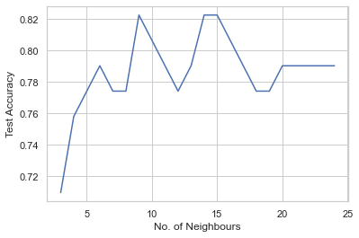

```python
# Plotting the curve of the K Neighbour vs accuracy
scores =[]
neighbour= range(3,25)
for k in neighbour:
    NNH = KNeighborsClassifier(n_neighbors = k, weights = 'distance' )
    NNH.fit(X_train, y_train)
    scores.append(NNH.score(X_test, y_test))

plt.plot(neighbour,scores)
plt.xlabel('No. of Neighbours')
plt.ylabel('Test Accuracy')
```

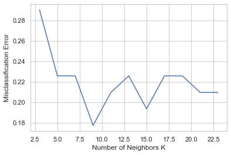

```python
# plot misclassification error vs k
plt.plot(neighbors, MSE)
plt.xlabel('Number of Neighbors K')
plt.ylabel('Misclassification Error')
plt.show()
```

```python
train_acc =[]
test_acc= []
neighbour= range(3,25)
for k in neighbour:
    NNH = KNeighborsClassifier(n_neighbors = k, weights = 'distance' )
    NNH.fit(X_train, y_train)
    train_acc.append(NNH.score(X_train, y_train))
    test_acc.append(NNH.score(X_test, y_test))
```

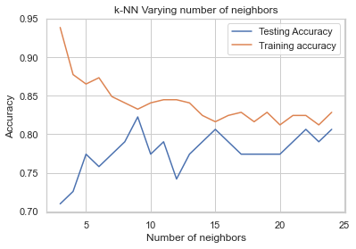

```python
# lets check the train and test accuracy for different values of neighbours present for the KNN model
train_acc =[]
test_acc= []
neighbors=range(3,25)
for k in neighbors:
    NNH = KNeighborsClassifier(n_neighbors = k)
    NNH.fit(X_train, y_train)
    y_pred = NNH.predict(X_test)
    train_acc.append(NNH.score(X_train, y_train))
    test_acc.append(NNH.score(X_test, y_test))

plt.title('k-NN Varying number of neighbors')
plt.plot(neighbors, test_acc, label='Testing Accuracy')
plt.plot(neighbors, train_acc, label='Training accuracy')
plt.legend()
plt.xlabel('Number of neighbors')
plt.ylabel('Accuracy')
plt.show()
```

Training and testing accuracy nears equal with the increase in neighbours.

We had found in our analysis that the target is imbalanced. So let's check if balancing the target improves the model or no. We shall use Smote for target balancing here.

```python
tb = SMOTE(random_state = 14)
Xtb_train,ytb_train = tb.fit_resample(X_train, y_train)
Xtb_test,ytb_test = tb.fit_resample(X_test, y_test)
```

```python
c_train = Counter(ytb_train)
c_test = Counter(ytb_test)
print("Count of Each Class in the Training Dataset: ", c_train)
print("Count of Each Class in the Test Dataset: ", c_test)
```

```
Count of Each Class in the Training Dataset:  Counter({'Type_S': 119, 'Type_H': 119, 'Normal': 119})
Count of Each Class in the Test Dataset:  Counter({'Type_H': 30, 'Normal': 30, 'Type_S': 30})
```

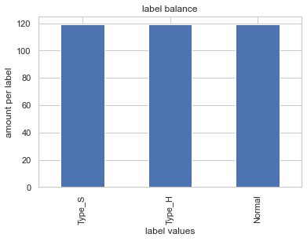

```python
#Now we have balance in the target class. Depicting it using the bar plot
ytb_train.value_counts().plot(kind='bar')
plt.title('label balance')
plt.xlabel('label values')
plt.ylabel('amount per label')
plt.show()
```

```python
# Checking the optimal value after implementing the target balancing
# empty list that will hold accuracy scores
myList = list(range(1,357))
# subsetting just the odd ones
neighbors = list(filter(lambda x: x % 2 != 0, myList))
ac_scores = []

# perform accuracy metrics for values from 10, 13, ...24
for k in neighbors:
    knn = KNeighborsClassifier(n_neighbors=k)
    knn.fit(Xtb_train, ytb_train)
    # predict the response
    y_pred = knn.predict(Xtb_test)
    # evaluate accuracy
    scores = accuracy_score(ytb_test, y_pred)
    ac_scores.append(scores)

# changing to misclassification error
MSE = [1 - x for x in ac_scores]

# determining best k
optimal_k = neighbors[MSE.index(min(MSE))]
print("The optimal number of neighbors after target balancing is %d" % optimal_k)
```

```
The optimal number of neighbors after target balancing is 17
```

```python
knn = KNeighborsClassifier(n_neighbors=optimal_k)
knn.fit(Xtb_train, ytb_train)
# predict the response
y_pred = knn.predict(Xtb_test)
confusion= confusion_matrix(ytb_test, y_pred)

print('Accuracy of Training Data for Optimal K: ', knn.score(Xtb_train, ytb_train))
print('Accuracy of Testing Data Optimal K: ', knn.score(Xtb_test, ytb_test))
print('\n')
print('Confusion Matrix:-->\n')
print(confusion)
print('\n')
print("Classification Report:--> \n", classification_report(ytb_test, y_pred))
```

```
Accuracy of Training Data for Optimal K:  0.8011204481792717
Accuracy of Testing Data Optimal K:  0.8555555555555555


Confusion Matrix:-->

[[25  4  1]
 [ 4 26  0]
 [ 1  3 26]]


Classification Report:-->
               precision    recall  f1-score   support

      Normal       0.83      0.83      0.83        30
      Type_H       0.79      0.87      0.83        30
      Type_S       0.96      0.87      0.91        30

    accuracy                           0.86        90
   macro avg       0.86      0.86      0.86        90
weighted avg       0.86      0.86      0.86        90
```

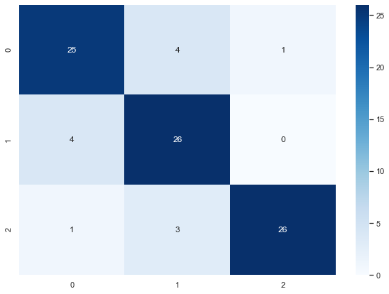

```python
# Plotting heatmap for visualization of confusion matrics
# Display confusion matrix
df_conf_mat = pd.DataFrame(confusion)
plt.figure(figsize = (10,7))
sns.heatmap(df_conf_mat, annot=True,cmap='Blues', fmt='g')
```

*Inference*

- After target balancing the target the model increased significantly
- The testing Accuracy of the model even surpassed the training accuracy
- There is a good improvement in precison recall and f1score as well for type_H.
- The f1 score for Type_S and recall value for type_s and normal has slightly decreased.
- Hence the optimal model with balanced target is achieved at 17 neighbours for our model.

**Conclusion**

- From the plots it was clear that distinction between the 3 class was not very optimal.
- The Class type_H and type_S was better interpretatble as after seggregating the normal values to boundaries could be better visualized
- The optimal value of KNN was achived but still a significant amount of misclassification was observed
- The balancing of target can help achieve better model, indicating that the distribution of the data could be improved in the dataset

## Part 2

- CONTEXT: A bank X is on a massive digital transformation for all its departments. Bank has a growing customer base whee majority of them are liability customers (depositors) vs borrowers (asset customers). The bank is interested in expanding the borrowers base rapidly to bring in more business via loan interests. A campaign that the bank ran in last quarter showed an average single digit conversion rate. Digital transformation being the core strength of the business strategy, marketing department wants to devise effective campaigns with better target marketing to increase the conversion ratio to double digit with same budget as per last campaign.
- DATA DESCRIPTION: The data consists of the following attributes:
1. ID: Customer ID
2. Age Customer’s approximate age.
3. CustomerSince: Customer of the bank since. [unit is masked]
4. HighestSpend: Customer’s highest spend so far in one transaction. [unit is masked]
5. ZipCode: Customer’s zip code.
6. HiddenScore: A score associated to the customer which is masked by the bank as an IP.
7. MonthlyAverageSpend: Customer’s monthly average spend so far. [unit is masked]
8. Level: A level associated to the customer which is masked by the bank as an IP.
9. Mortgage: Customer’s mortgage. [unit is masked]
10. Security: Customer’s security asset with the bank. [unit is masked]
11. FixedDepositAccount: Customer’s fixed deposit account with the bank. [unit is masked]
12. InternetBanking: if the customer uses internet banking.
13. CreditCard: if the customer uses bank’s credit card.
14. LoanOnCard: if the customer has a loan on credit card.

**1. Import and warehouse data:**

- Import all the given datasets and explore shape and size of each.
- Merge all datasets onto one and explore final shape and size.

```python
#loading the datasets and forming one dataframe
df01=pd.read_csv('Part2 - Data1.csv')
df02=pd.read_csv('Part2 -Data2.csv')
#Joining the dataset on column ID
df=df01.join(df02.set_index('ID'), how='left', on='ID')
```

```python
#Checking the size of each dataframe and final data frame after concatinating all of them together
print('Shape of df01: ', df01.shape)
print('Shape of df02: ', df02.shape)
print('Shape of data (The concatinated dataframe): ', df.shape)
```

```
Shape of df01:  (5000, 8)
Shape of df02:  (5000, 7)
Shape of data (The concatinated dataframe):  (5000, 14)
```

```python
#checking on how the data looks
df.head()
```

|  | ID | Age | CustomerSince | HighestSpend | ZipCode | HiddenScore | MonthlyAverageSpend | Level | Mortgage | Security | FixedDepositAccount | InternetBanking | CreditCard | LoanOnCard |
| --- | --- | --- | --- | --- | --- | --- | --- | --- | --- | --- | --- | --- | --- | --- |
| 0 | 1 | 25 | 1 | 49 | 91107 | 4 | 1.6 | 1 | 0 | 1 | 0 | 0 | 0 | NaN |
| 1 | 2 | 45 | 19 | 34 | 90089 | 3 | 1.5 | 1 | 0 | 1 | 0 | 0 | 0 | NaN |
| 2 | 3 | 39 | 15 | 11 | 94720 | 1 | 1.0 | 1 | 0 | 0 | 0 | 0 | 0 | NaN |
| 3 | 4 | 35 | 9 | 100 | 94112 | 1 | 2.7 | 2 | 0 | 0 | 0 | 0 | 0 | NaN |
| 4 | 5 | 35 | 8 | 45 | 91330 | 4 | 1.0 | 2 | 0 | 0 | 0 | 0 | 1 | NaN |

```python
#Checking the size of the final dataframe
df.size
```

```
70000
```

**2. Data cleansing:**

- Explore and if required correct the datatypes of each attribute
- Explore for null values in the attributes and if required drop or impute values.

```python
#checking the information of loaded dataset. Dtypes are as expected
df.info()
```

```
<class 'pandas.core.frame.DataFrame'>
RangeIndex: 5000 entries, 0 to 4999
Data columns (total 14 columns):
 #   Column               Non-Null Count  Dtype
---  ------               --------------  -----
 0   ID                   5000 non-null   int64
 1   Age                  5000 non-null   int64
 2   CustomerSince        5000 non-null   int64
 3   HighestSpend         5000 non-null   int64
 4   ZipCode              5000 non-null   int64
 5   HiddenScore          5000 non-null   int64
 6   MonthlyAverageSpend  5000 non-null   float64
 7   Level                5000 non-null   int64
 8   Mortgage             5000 non-null   int64
 9   Security             5000 non-null   int64
 10  FixedDepositAccount  5000 non-null   int64
 11  InternetBanking      5000 non-null   int64
 12  CreditCard           5000 non-null   int64
 13  LoanOnCard           4980 non-null   float64
dtypes: float64(2), int64(12)
memory usage: 547.0 KB
```

- Loan on Card appears to have null values present in it.
- Either a value would require to be imputed or the Nan values should be dropped

```python
#performing 5 point summary
df.describe()
```

|  | ID | Age | CustomerSince | HighestSpend | ZipCode | HiddenScore | MonthlyAverageSpend | Level | Mortgage | Security | FixedDepositAccount | InternetBanking | CreditCard | LoanOnCard |
| --- | --- | --- | --- | --- | --- | --- | --- | --- | --- | --- | --- | --- | --- | --- |
| count | 5000.000000 | 5000.000000 | 5000.000000 | 5000.000000 | 5000.000000 | 5000.000000 | 5000.000000 | 5000.000000 | 5000.000000 | 5000.000000 | 5000.00000 | 5000.000000 | 5000.000000 | 4980.000000 |
| mean | 2500.500000 | 45.338400 | 20.104600 | 73.774200 | 93152.503000 | 2.396400 | 1.937938 | 1.881000 | 56.498800 | 0.104400 | 0.06040 | 0.596800 | 0.294000 | 0.096386 |
| std | 1443.520003 | 11.463166 | 11.467954 | 46.033729 | 2121.852197 | 1.147663 | 1.747659 | 0.839869 | 101.713802 | 0.305809 | 0.23825 | 0.490589 | 0.455637 | 0.295149 |
| min | 1.000000 | 23.000000 | -3.000000 | 8.000000 | 9307.000000 | 1.000000 | 0.000000 | 1.000000 | 0.000000 | 0.000000 | 0.00000 | 0.000000 | 0.000000 | 0.000000 |
| 25% | 1250.750000 | 35.000000 | 10.000000 | 39.000000 | 91911.000000 | 1.000000 | 0.700000 | 1.000000 | 0.000000 | 0.000000 | 0.00000 | 0.000000 | 0.000000 | 0.000000 |
| 50% | 2500.500000 | 45.000000 | 20.000000 | 64.000000 | 93437.000000 | 2.000000 | 1.500000 | 2.000000 | 0.000000 | 0.000000 | 0.00000 | 1.000000 | 0.000000 | 0.000000 |
| 75% | 3750.250000 | 55.000000 | 30.000000 | 98.000000 | 94608.000000 | 3.000000 | 2.500000 | 3.000000 | 101.000000 | 0.000000 | 0.00000 | 1.000000 | 1.000000 | 0.000000 |
| max | 5000.000000 | 67.000000 | 43.000000 | 224.000000 | 96651.000000 | 4.000000 | 10.000000 | 3.000000 | 635.000000 | 1.000000 | 1.00000 | 1.000000 | 1.000000 | 1.000000 |

- CustomerSince column which appears to be the no of years has negative values
- Since the no of years cannot be negative we will make modifications to the column

```python
#checking the presence of null in the dataset
df.isnull().any()
```

```
ID                     False
Age                    False
CustomerSince          False
HighestSpend           False
ZipCode                False
HiddenScore            False
MonthlyAverageSpend    False
Level                  False
Mortgage               False
Security               False
FixedDepositAccount    False
InternetBanking        False
CreditCard             False
LoanOnCard              True
dtype: bool
```

```python
#Describing the data, we found that the CustomerSince column is giving out negative values also, hence checking all those.
df[df['CustomerSince']<=0].CustomerSince.unique()
```

```
array([-1,  0, -2, -3], dtype=int64)
```

```python
#since the unit of CustomerSince column is masked, it supposedly assumes it to start from a paeticular year (marked as 0 in the dataset)
#hence modifing to make proper CustomerSince, so that it doesnot have a negative value.
# finding the total years a customer has been associated with the bank, cust_totl_year
#inorder to negate negative values ranging till -3 adding 3 to CustomerSince and creating a new column

df['Cust_Totl_Year']=df['CustomerSince']+3
```

Assuming the below mentioned:

2. LoanOnCard = 1 --> Customer has taken the loan on the card
- LoanOnCard = 0 --> Customer doesnot have a loan on the card
1. Nan values for LoanOnCard to be Customer doesnot have a loan on the card.
- Hence will fill the NaN values with a '0'

```python
#Handling the null found in the LoanOnCard column and filling it with zero
df['LoanOnCard']=df['LoanOnCard'].fillna(0)
```

```python
#Again checking the presence of null values
df.isnull().any().any()
```

```
False
```

```python
#Checking the values of the column LoanOnCard to find out if the null was properly filled
df.LoanOnCard.unique()
```

```
array([0., 1.])
```

```python
# checking the uniques in the zipcode
df.ZipCode.unique()
```

```
array([91107, 90089, 94720, 94112, 91330, 92121, 91711, 93943, 93023,
       94710, 90277, 93106, 94920, 91741, 95054, 95010, 94305, 91604,
       94015, 90095, 91320, 95521, 95064, 90064, 94539, 94104, 94117,
       94801, 94035, 92647, 95814, 94114, 94115, 92672, 94122, 90019,
       95616, 94065, 95014, 91380, 95747, 92373, 92093, 94005, 90245,
       95819, 94022, 90404, 93407, 94523, 90024, 91360, 95670, 95123,
       90045, 91335, 93907, 92007, 94606, 94611, 94901, 92220, 93305,
       95134, 94612, 92507, 91730, 94501, 94303, 94105, 94550, 92612,
       95617, 92374, 94080, 94608, 93555, 93311, 94704, 92717, 92037,
       95136, 94542, 94143, 91775, 92703, 92354, 92024, 92831, 92833,
       94304, 90057, 92130, 91301, 92096, 92646, 92182, 92131, 93720,
       90840, 95035, 93010, 94928, 95831, 91770, 90007, 94102, 91423,
       93955, 94107, 92834, 93117, 94551, 94596, 94025, 94545, 95053,
       90036, 91125, 95120, 94706, 95827, 90503, 90250, 95817, 95503,
       93111, 94132, 95818, 91942, 90401, 93524, 95133, 92173, 94043,
```

[output cut: 38 more lines]

Since zipcodes are realted to area and the presence of mutipliple zipcodes is not going to provide any significance to the dataset

```python
# Checking the correlation value
df.corr()
```

|  | ID | Age | CustomerSince | HighestSpend | ZipCode | HiddenScore | MonthlyAverageSpend | Level | Mortgage | Security | FixedDepositAccount | InternetBanking | CreditCard | LoanOnCard | Cust_Totl_Year |
| --- | --- | --- | --- | --- | --- | --- | --- | --- | --- | --- | --- | --- | --- | --- | --- |
| ID | 1.000000 | -0.008473 | -0.008326 | -0.017695 | 0.013432 | -0.016797 | -0.024675 | 0.021463 | -0.013920 | -0.016972 | -0.006909 | -0.002528 | 0.017028 | -0.024801 | -0.008326 |
| Age | -0.008473 | 1.000000 | 0.994215 | -0.055269 | -0.029216 | -0.046418 | -0.052012 | 0.041334 | -0.012539 | -0.000436 | 0.008043 | 0.013702 | 0.007681 | -0.007726 | 0.994215 |
| CustomerSince | -0.008326 | 0.994215 | 1.000000 | -0.046574 | -0.028626 | -0.052563 | -0.050077 | 0.013152 | -0.010582 | -0.001232 | 0.010353 | 0.013898 | 0.008967 | -0.007413 | 1.000000 |
| HighestSpend | -0.017695 | -0.055269 | -0.046574 | 1.000000 | -0.016410 | -0.157501 | 0.645984 | -0.187524 | 0.206806 | -0.002616 | 0.169738 | 0.014206 | -0.002385 | 0.502462 | -0.046574 |
| ZipCode | 0.013432 | -0.029216 | -0.028626 | -0.016410 | 1.000000 | 0.011778 | -0.004061 | -0.017377 | 0.007383 | 0.004704 | 0.019972 | 0.016990 | 0.007691 | 0.000107 | -0.028626 |
| HiddenScore | -0.016797 | -0.046418 | -0.052563 | -0.157501 | 0.011778 | 1.000000 | -0.109275 | 0.064929 | -0.020445 | 0.019994 | 0.014110 | 0.010354 | 0.011588 | 0.061367 | -0.052563 |
| MonthlyAverageSpend | -0.024675 | -0.052012 | -0.050077 | 0.645984 | -0.004061 | -0.109275 | 1.000000 | -0.136124 | 0.109905 | 0.015086 | 0.136534 | -0.003611 | -0.006689 | 0.366889 | -0.050077 |
| Level | 0.021463 | 0.041334 | 0.013152 | -0.187524 | -0.017377 | 0.064929 | -0.136124 | 1.000000 | -0.033327 | -0.010812 | 0.013934 | -0.015004 | -0.011014 | 0.136722 | 0.013152 |
| Mortgage | -0.013920 | -0.012539 | -0.010582 | 0.206806 | 0.007383 | -0.020445 | 0.109905 | -0.033327 | 1.000000 | -0.005411 | 0.089311 | -0.005995 | -0.007231 | 0.142095 | -0.010582 |
| Security | -0.016972 | -0.000436 | -0.001232 | -0.002616 | 0.004704 | 0.019994 | 0.015086 | -0.010812 | -0.005411 | 1.000000 | 0.317034 | 0.012627 | -0.015028 | 0.021954 | -0.001232 |
| FixedDepositAccount | -0.006909 | 0.008043 | 0.010353 | 0.169738 | 0.019972 | 0.014110 | 0.136534 | 0.013934 | 0.089311 | 0.317034 | 1.000000 | 0.175880 | 0.278644 | 0.316355 | 0.010353 |
| InternetBanking | -0.002528 | 0.013702 | 0.013898 | 0.014206 | 0.016990 | 0.010354 | -0.003611 | -0.015004 | -0.005995 | 0.012627 | 0.175880 | 1.000000 | 0.004210 | 0.006278 | 0.013898 |
| CreditCard | 0.017028 | 0.007681 | 0.008967 | -0.002385 | 0.007691 | 0.011588 | -0.006689 | -0.011014 | -0.007231 | -0.015028 | 0.278644 | 0.004210 | 1.000000 | 0.002802 | 0.008967 |
| LoanOnCard | -0.024801 | -0.007726 | -0.007413 | 0.502462 | 0.000107 | 0.061367 | 0.366889 | 0.136722 | 0.142095 | 0.021954 | 0.316355 | 0.006278 | 0.002802 | 1.000000 | -0.007413 |
| Cust_Totl_Year | -0.008326 | 0.994215 | 1.000000 | -0.046574 | -0.028626 | -0.052563 | -0.050077 | 0.013152 | -0.010582 | -0.001232 | 0.010353 | 0.013898 | 0.008967 | -0.007413 | 1.000000 |

The Zip code has no strong correlation with any of the other features and hence can be dropped out

```python
#removing the redundant columns
df=df.drop(['ID','ZipCode','CustomerSince'], axis=1)
```

```python
#checking the data after performing some data cleaning
df.head()
```

|  | Age | HighestSpend | HiddenScore | MonthlyAverageSpend | Level | Mortgage | Security | FixedDepositAccount | InternetBanking | CreditCard | LoanOnCard | Cust_Totl_Year |
| --- | --- | --- | --- | --- | --- | --- | --- | --- | --- | --- | --- | --- |
| 0 | 25 | 49 | 4 | 1.6 | 1 | 0 | 1 | 0 | 0 | 0 | 0.0 | 4 |
| 1 | 45 | 34 | 3 | 1.5 | 1 | 0 | 1 | 0 | 0 | 0 | 0.0 | 22 |
| 2 | 39 | 11 | 1 | 1.0 | 1 | 0 | 0 | 0 | 0 | 0 | 0.0 | 18 |
| 3 | 35 | 100 | 1 | 2.7 | 2 | 0 | 0 | 0 | 0 | 0 | 0.0 | 12 |
| 4 | 35 | 45 | 4 | 1.0 | 2 | 0 | 0 | 0 | 0 | 1 | 0.0 | 11 |

**3. Data analysis & visualisation:**

- Perform detailed statistical analysis on the data.
- Perform a detailed univariate, bivariate and multivariate analysis with appropriate detailed comments after each analysis.

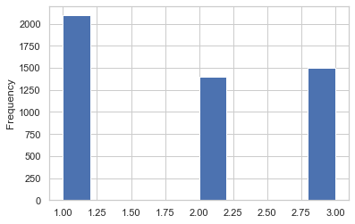

```python
'''Finding the no of people on the 3 levels (Assuming the level 1 is the lowest and level 3 is the highest
since the unit of level column is masked)
'''

df1 = df.groupby(['Age'])['Level'].sum().reset_index()
df['Level'].plot(kind='hist')
```

```python
# Bining(Grouping) the data based on the age.
bins = [20, 30, 40, 50, 60, 70]
labels = ['20-29', '30-39', '40-49', '50-59', '60+']
df['AgeRange'] = pd.cut(df.Age, bins, labels = labels,include_lowest = True)
```

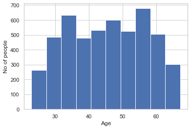

```python
# Plotting the groph to see the distribution of Age of the customers
plt.hist(df['Age'], histtype= 'bar', bins=10)
plt.xlabel('Age')
plt.ylabel('No of people')
```

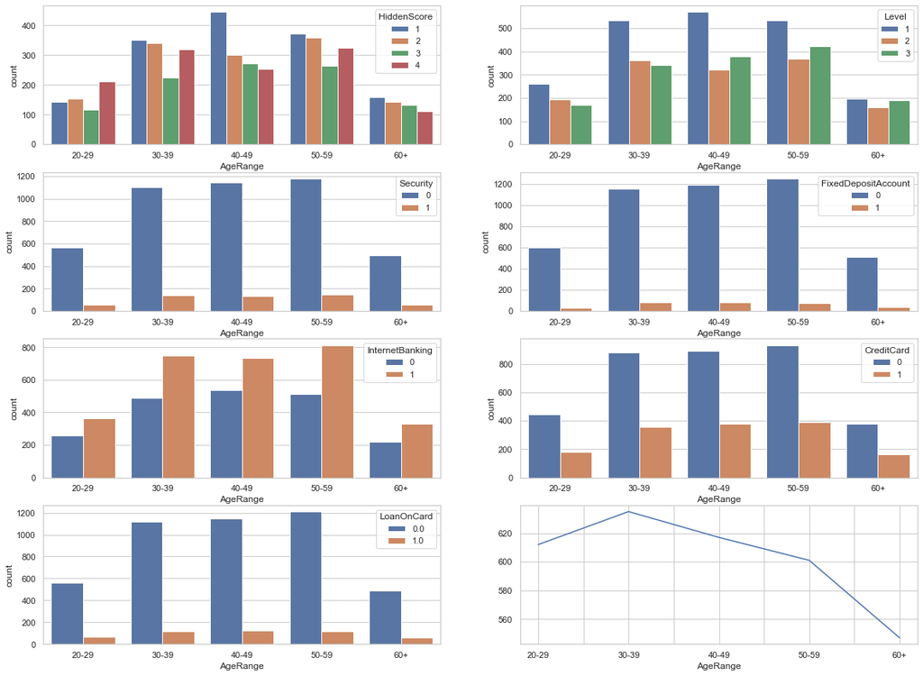

```python
# for each age range, lets check the values of each column to get some infrence about the distribution based on
# the age group of the customers associated with the bank
fig, ax =plt.subplots(4,2, figsize=(20,15))


sns.countplot(x='AgeRange',hue='HiddenScore', data=df, ax=ax[0][0])
sns.countplot(x='AgeRange',hue='Level', data=df, ax=ax[0][1])
sns.countplot(x='AgeRange',hue='Security', data=df, ax=ax[1][0])
sns.countplot(x='AgeRange',hue='FixedDepositAccount', data=df, ax=ax[1][1])
sns.countplot(x='AgeRange',hue='InternetBanking', data=df, ax=ax[2][0])
sns.countplot(x='AgeRange',hue='CreditCard', data=df, ax=ax[2][1])
sns.countplot(x='AgeRange',hue='LoanOnCard', data=df, ax=ax[3][0])

#ploting the maximum mortage taken by each age range
df.groupby(['AgeRange'])['Mortgage'].max().plot(ax=ax[3][1])
```

```python
# find the maximum amount of mortage a given age group has taken. Minimum for each range is zero
print("\n----------- Maximum -----------\n")
print(df.groupby(['AgeRange'])['Mortgage'].max())
```

```
----------- Maximum -----------

AgeRange
20-29    612
30-39    635
40-49    617
50-59    601
60+      547
Name: Mortgage, dtype: int64
```

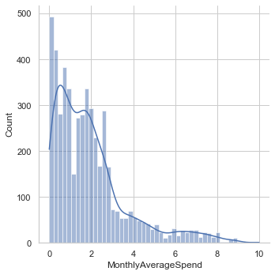

```python
sns.displot(df['MonthlyAverageSpend'], kind='hist', kde=True)
```

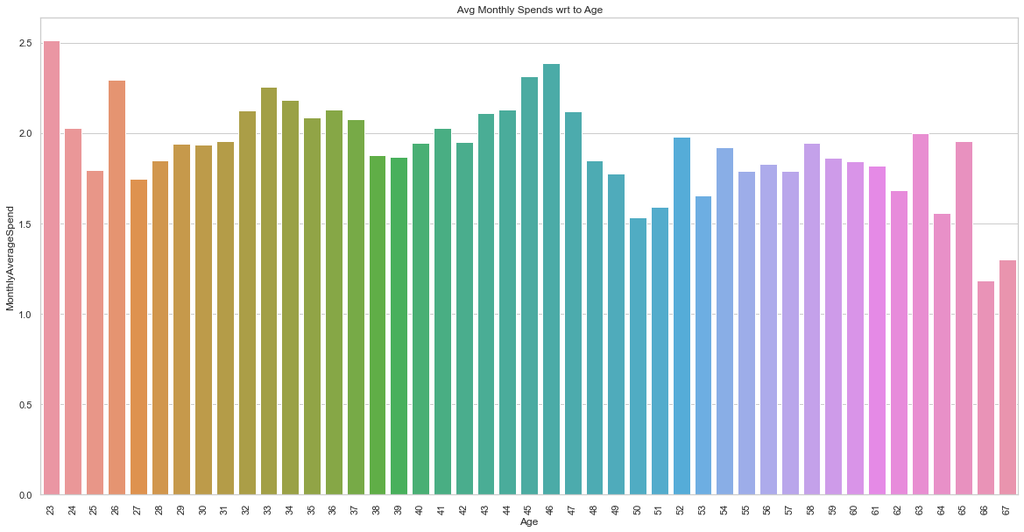

```python
plt.figure(figsize=(20,10))
fig = sns.barplot(x='Age',
                   y='MonthlyAverageSpend',
                   data= df, ci=None)
fig.set_xticklabels(fig.get_xticklabels(), rotation=90)
temp = fig.set_title(' Avg Monthly Spends wrt to Age')
```

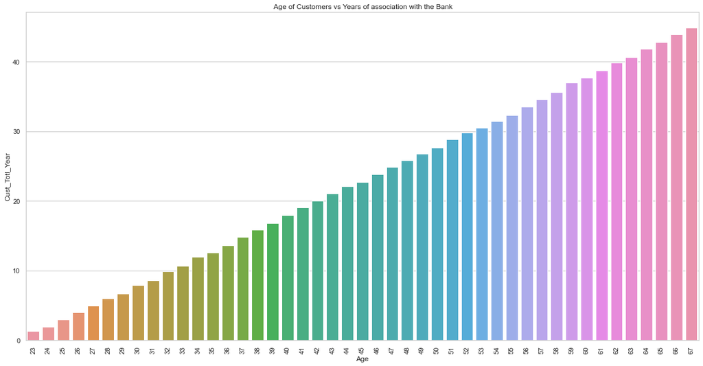

```python
plt.figure(figsize=(20,10))
fig = sns.barplot(x='Age',
                   y='Cust_Totl_Year',
                   data= df, ci=None)
fig.set_xticklabels(fig.get_xticklabels(), rotation=90)
temp = fig.set_title(' Age of Customers vs Years of association with the Bank')
```

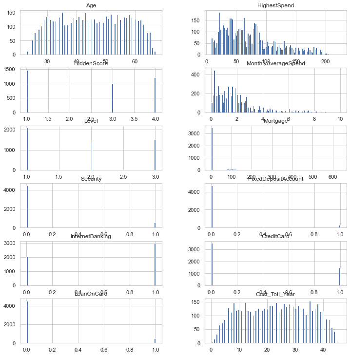

```python
columns = list(df)[0:-1] # Excluding Outcome column which has only
df[columns].hist(stacked=False, bins=100, figsize=(12,30), layout=(14,2));
# Histogram of the columns
```

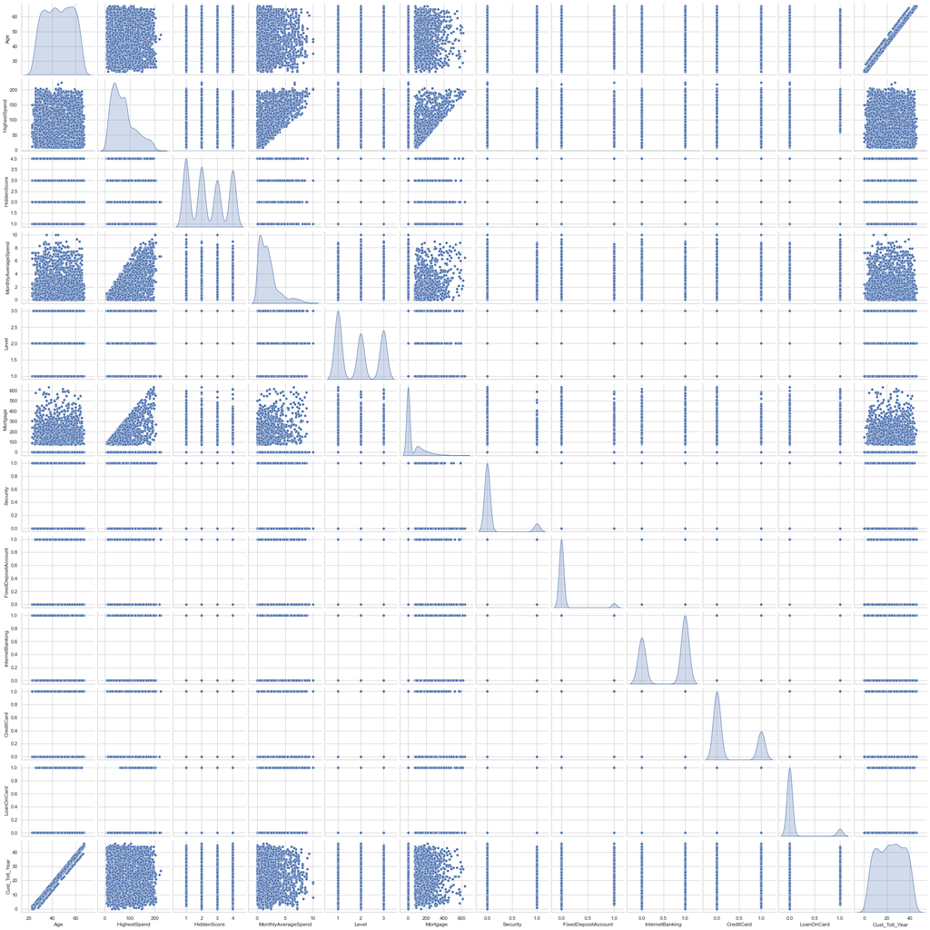

```python
#Plotting the realtionship between all the variables present in the dataset
sns.pairplot(df,diag_kind='kde')
```

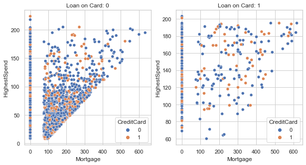

```python
# A similar notion thing can be established using the graph
fig, ax =plt.subplots(1,2, figsize=(10,5))
sns.scatterplot(x="Mortgage", y="HighestSpend", hue="CreditCard", data=df[df.LoanOnCard==0], ax=ax[0])
ax[0].set_title('Loan on Card: 0')
sns.scatterplot(x="Mortgage", y="HighestSpend", hue="CreditCard", data=df[df.LoanOnCard==1], ax=ax[1])
ax[1].set_title('Loan on Card: 1')
```

*Inference*

- From the above graph, there appers to be a significant correlation between customers with mortgage and Higher spends and seems to be the potential ones for loan amounting

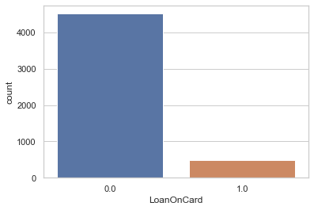

```python
# Checking the frequency of LoanOnCard
sns.countplot(x='LoanOnCard', data=df)
```

- As evident, a significant amount of people donot have loan on their card
- This will impose a target imbalancing issue and may effect the accuracy of the model

Performing Chi Square test to check the relation between the variables

```python
# Performing Chi Square test to check if the person has CreditCard they have the loan on their card
contingency_table=pd.crosstab(df["CreditCard"],df["LoanOnCard"])
print('contingency_table :-\n',contingency_table)
```

```
contingency_table :-
 LoanOnCard   0.0  1.0
CreditCard
0           3193  337
1           1327  143
```

```python
Observed_Values = contingency_table.values
b=scipy.stats.chi2_contingency(contingency_table)
Expected_Values = b[3]
print("Expected Values :-\n",Expected_Values)
no_of_rows=len(contingency_table.iloc[0:2,0])
no_of_columns=len(contingency_table.iloc[0,0:2])
dof=(no_of_rows-1)*(no_of_columns-1)
print("Degree of Freedom:-",dof)
```

```
Expected Values :-
 [[3191.12  338.88]
 [1328.88  141.12]]
Degree of Freedom:- 1
```

```python
# Setting significance level to be 5 %
alpha=0.05
chi_square=sum([(o-e)**2./e for o,e in zip(Observed_Values,Expected_Values)])
chi_square_statistic=chi_square[0]+chi_square[1]
print("chi-square statistic:-",chi_square_statistic)
critical_value=chi2.ppf(q=1-alpha,df=dof)
print('critical_value:',critical_value)
```

```
chi-square statistic:- 0.03924225894658156
critical_value: 3.841458820694124
```

```python
p_value=1-chi2.cdf(x=chi_square_statistic,df=dof)
print('p-value:',p_value)
```

```
p-value: 0.8429694927995713
```

```python
print('Significance level: ',alpha)
print('Degree of Freedom: ',dof)
print('chi-square statistic:',chi_square_statistic)
print('critical_value:',critical_value)
print('p-value:',p_value)
```

```
Significance level:  0.05
Degree of Freedom:  1
chi-square statistic: 0.03924225894658156
critical_value: 3.841458820694124
p-value: 0.8429694927995713
```

```python
#compare chi_square_statistic with critical_value and p-value which is the probability of getting chi-square>0.09 (chi_square_statistic)
if chi_square_statistic>=critical_value:
    print("Reject H0,There is a relationship between 2 variables")
else:
    print("Retain H0,There is no relationship between 2 variables")

if p_value<=alpha:
    print("Reject H0,There is a relationship between 2 variables")
else:
    print("Retain H0,There is no relationship between 2 variables")
```

```
Retain H0,There is no relationship between 2 variables
Retain H0,There is no relationship between 2 variables
```

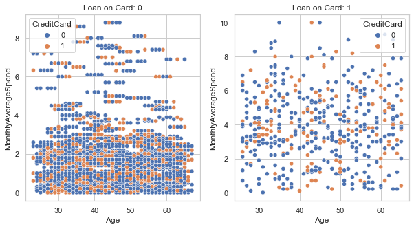

```python
# A similar notion thing can be established using the graph
fig, ax =plt.subplots(1,2, figsize=(10,5))
sns.scatterplot(x="Age", y="MonthlyAverageSpend", hue="CreditCard", data=df[df.LoanOnCard==0], ax=ax[0])
ax[0].set_title('Loan on Card: 0')
sns.scatterplot(x="Age", y="MonthlyAverageSpend", hue="CreditCard", data=df[df.LoanOnCard==1], ax=ax[1])
ax[1].set_title('Loan on Card: 1')
```

*Inference*

A person owing a CreditCard donot necessarily have the loan on their card

```python
df.head()
```

|  | Age | HighestSpend | HiddenScore | MonthlyAverageSpend | Level | Mortgage | Security | FixedDepositAccount | InternetBanking | CreditCard | LoanOnCard | Cust_Totl_Year | AgeRange |
| --- | --- | --- | --- | --- | --- | --- | --- | --- | --- | --- | --- | --- | --- |
| 0 | 25 | 49 | 4 | 1.6 | 1 | 0 | 1 | 0 | 0 | 0 | 0.0 | 4 | 20-29 |
| 1 | 45 | 34 | 3 | 1.5 | 1 | 0 | 1 | 0 | 0 | 0 | 0.0 | 22 | 40-49 |
| 2 | 39 | 11 | 1 | 1.0 | 1 | 0 | 0 | 0 | 0 | 0 | 0.0 | 18 | 30-39 |
| 3 | 35 | 100 | 1 | 2.7 | 2 | 0 | 0 | 0 | 0 | 0 | 0.0 | 12 | 30-39 |
| 4 | 35 | 45 | 4 | 1.0 | 2 | 0 | 0 | 0 | 0 | 1 | 0.0 | 11 | 30-39 |

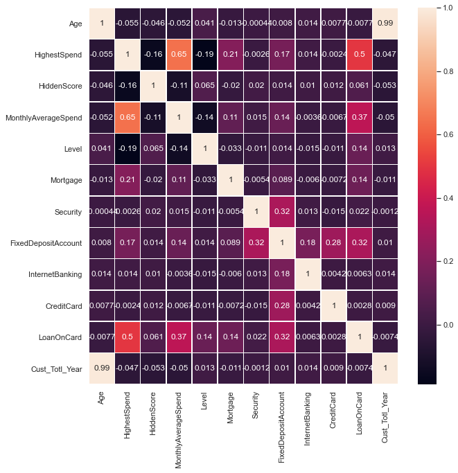

```python
fig, ax = plt.subplots(figsize=(10,10))         # Sample figsize in inches
sns.heatmap(df.corr(), annot=True, linewidths=.5, ax=ax)
```

*Inference*

- There is a very high correlation between Cust_Totl_Year and Age indicating a customer associated with the bank is mostly proportional
- There are many poorly correlated columns in the dataset

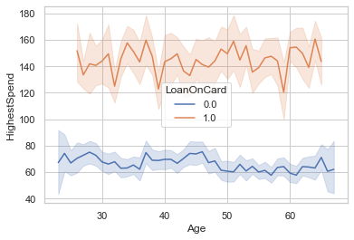

```python
#Lets check the relation between age and the amount spend basis LoanOnCard
sns.lineplot(x="Age", y="HighestSpend", hue="LoanOnCard", data=df);
```

*Inference*

- This is indicative that the spend of the customer is higher when the customer has a Loan on their card

**4. Data pre-processing:**

- Segregate predictors vs target attributes
- Check for target balancing and fix it if found imbalanced.
- Perform train-test split.

Spliting the data

```python
df.info()
```

```
<class 'pandas.core.frame.DataFrame'>
RangeIndex: 5000 entries, 0 to 4999
Data columns (total 13 columns):
 #   Column               Non-Null Count  Dtype
---  ------               --------------  -----
 0   Age                  5000 non-null   int64
 1   HighestSpend         5000 non-null   int64
 2   HiddenScore          5000 non-null   int64
 3   MonthlyAverageSpend  5000 non-null   float64
 4   Level                5000 non-null   int64
 5   Mortgage             5000 non-null   int64
 6   Security             5000 non-null   int64
 7   FixedDepositAccount  5000 non-null   int64
 8   InternetBanking      5000 non-null   int64
 9   CreditCard           5000 non-null   int64
 10  LoanOnCard           5000 non-null   float64
 11  Cust_Totl_Year       5000 non-null   int64
 12  AgeRange             5000 non-null   category
dtypes: category(1), float64(2), int64(10)
memory usage: 474.0 KB
```

```python
# lets build the logistic model
# independant variables
# Removing AgeRange as it is a categorical column
X = df.drop(['LoanOnCard','AgeRange'], axis=1)
# the dependent variable
y = df[['LoanOnCard']]
```

```python
# Since the values are masked for all the columns normalizing the data to have a uniform scaling
X_scaled = preprocessing.scale(X)
X_scaled = pd.DataFrame(X_scaled, columns=X.columns)
X_scaled.head()
```

|  | Age | HighestSpend | HiddenScore | MonthlyAverageSpend | Level | Mortgage | Security | FixedDepositAccount | InternetBanking | CreditCard | Cust_Totl_Year |
| --- | --- | --- | --- | --- | --- | --- | --- | --- | --- | --- | --- |
| 0 | -1.774417 | -0.538229 | 1.397414 | -0.193385 | -1.049078 | -0.555524 | 2.928915 | -0.25354 | -1.216618 | -0.645314 | -1.666078 |
| 1 | -0.029524 | -0.864109 | 0.525991 | -0.250611 | -1.049078 | -0.555524 | 2.928915 | -0.25354 | -1.216618 | -0.645314 | -0.096330 |
| 2 | -0.552992 | -1.363793 | -1.216855 | -0.536736 | -1.049078 | -0.555524 | -0.341423 | -0.25354 | -1.216618 | -0.645314 | -0.445163 |
| 3 | -0.901970 | 0.569765 | -1.216855 | 0.436091 | 0.141703 | -0.555524 | -0.341423 | -0.25354 | -1.216618 | -0.645314 | -0.968413 |
| 4 | -0.901970 | -0.625130 | 1.397414 | -0.536736 | 0.141703 | -0.555524 | -0.341423 | -0.25354 | -1.216618 | 1.549632 | -1.055621 |

```python
# Split X and y into training and test set in 70:30 ratio

X_train, X_test, y_train, y_test = train_test_split(X_scaled, y, test_size=0.30, random_state=1)
X_train.head()
```

|  | Age | HighestSpend | HiddenScore | MonthlyAverageSpend | Level | Mortgage | Security | FixedDepositAccount | InternetBanking | CreditCard | Cust_Totl_Year |
| --- | --- | --- | --- | --- | --- | --- | --- | --- | --- | --- | --- |
| 1334 | 0.144966 | -0.842384 | -0.345432 | -0.365061 | -1.049078 | -0.555524 | -0.341423 | -0.25354 | 0.821951 | -0.645314 | 0.165294 |
| 4768 | -0.640236 | -0.755483 | -1.216855 | 0.035515 | 0.141703 | -0.555524 | -0.341423 | -0.25354 | 0.821951 | -0.645314 | -0.532371 |
| 65 | 1.191902 | 1.243252 | -1.216855 | 1.065567 | -1.049078 | -0.555524 | -0.341423 | -0.25354 | 0.821951 | 1.549632 | 1.299002 |
| 177 | -1.425438 | -0.190623 | 1.397414 | -0.078935 | 0.141703 | 1.843604 | -0.341423 | -0.25354 | -1.216618 | -0.645314 | -1.491662 |
| 4489 | -0.552992 | -1.146539 | 0.525991 | -0.994537 | 0.141703 | -0.555524 | -0.341423 | -0.25354 | 0.821951 | -0.645314 | -0.619580 |

Checking the split of the data

```python
print("{0:0.2f}% data is in training set".format((len(X_train)/len(df.index)) * 100))
print("{0:0.2f}% data is in test set".format((len(X_test)/len(df.index)) * 100))
```

```
70.00% data is in training set
30.00% data is in test set
```

```python
print("Original Diabetes True Values    : {0} ({1:0.2f}%)".format(len(df.loc[df['LoanOnCard'] == 1]), (len(df.loc[df['LoanOnCard'] == 1])/len(df.index)) * 100))
print("Original Diabetes False Values   : {0} ({1:0.2f}%)".format(len(df.loc[df['LoanOnCard'] == 0]), (len(df.loc[df['LoanOnCard'] == 0])/len(df.index)) * 100))
print("")
print("Training Diabetes True Values    : {0} ({1:0.2f}%)".format(len(y_train[y_train[:] == 1]), (len(y_train[y_train[:] == 1])/len(y_train)) * 100))
print("Training Diabetes False Values   : {0} ({1:0.2f}%)".format(len(y_train[y_train[:] == 0]), (len(y_train[y_train[:] == 0])/len(y_train)) * 100))
print("")
print("Test Diabetes True Values        : {0} ({1:0.2f}%)".format(len(y_test[y_test[:] == 1]), (len(y_test[y_test[:] == 1])/len(y_test)) * 100))
print("Test Diabetes False Values       : {0} ({1:0.2f}%)".format(len(y_test[y_test[:] == 0]), (len(y_test[y_test[:] == 0])/len(y_test)) * 100))
print("")
```

```
Original Diabetes True Values    : 480 (9.60%)
Original Diabetes False Values   : 4520 (90.40%)

Training Diabetes True Values    : 3500 (100.00%)
Training Diabetes False Values   : 3500 (100.00%)

Test Diabetes True Values        : 1500 (100.00%)
Test Diabetes False Values       : 1500 (100.00%)
```

```python
y_train.value_counts() # imbalance in the given dataset found
```

```
LoanOnCard
0.0           3169
1.0            331
dtype: int64
```

```python
y_test.value_counts()
```

```
LoanOnCard
0.0           1351
1.0            149
dtype: int64
```

**5. Model training, testing and tuning:**

- Design and train a Logistic regression and Naive Bayes classifiers.
- Display the classification accuracies for train and test data.
- Display and explain the classification report in detail.
- Apply all the possible tuning techniques to train the best model for the given data. Select the final best trained model with your comments for selecting this model.

```python
regression_model = LogisticRegression(solver="liblinear")
regression_model.fit(X_train, y_train)
```

```
LogisticRegression(solver='liblinear')
```

```python
#out of sample score (R^2)

print('Score of the training dataset: ', regression_model.score(X_train, y_train))
print('Score of the testing dataset: ', regression_model.score(X_test,y_test))
```

```
Score of the training dataset:  0.9531428571428572
Score of the testing dataset:  0.948
```

```python
#Checking the target column and the counts
df.LoanOnCard.value_counts()
# the target column is imbalanced. Hence would require implementation of target balancing techniques
```

```
0.0    4520
1.0     480
Name: LoanOnCard, dtype: int64
```

```python
y_preds = regression_model.predict(X_test)
y_preds = np.round(y_preds)

print("Classification Report: \n", classification_report(y_test, y_preds))
# Also upon checking, it performs badly wrt to recall and f1 score
```

```
Classification Report:
               precision    recall  f1-score   support

         0.0       0.96      0.99      0.97      1351
         1.0       0.84      0.58      0.69       149

    accuracy                           0.95      1500
   macro avg       0.90      0.79      0.83      1500
weighted avg       0.94      0.95      0.94      1500
```

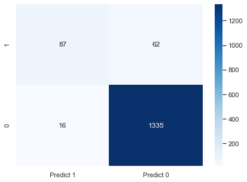

```python
# Checking the confusion metrics

cm=metrics.confusion_matrix(y_test, y_preds, labels=[1, 0])

df_cm = pd.DataFrame(cm, index = [i for i in ["1","0"]],
                  columns = [i for i in ["Predict 1","Predict 0"]])
plt.figure(figsize = (7,5))
sns.heatmap(df_cm, annot=True, cmap='Blues', fmt='g')
```

The confusion matrix

```
No Skill: ROC AUC=0.500
Logistic: ROC AUC=0.786
```

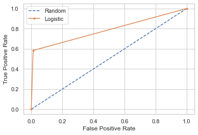

```python
ns_probs = [0 for _ in range(len(y_test))]
ns_auc = roc_auc_score(y_test, ns_probs)
lr_auc = roc_auc_score(y_test, y_preds)

#find ROC score:
print('No Skill: ROC AUC=%.3f' % (ns_auc))
print('Logistic: ROC AUC=%.3f' % (lr_auc))

# calculate roc curves
ns_fpr, ns_tpr, _ = roc_curve(y_test, ns_probs)
lr_fpr, lr_tpr, _ = roc_curve(y_test, y_preds)

# plot the roc curve for the model
plt.plot(ns_fpr, ns_tpr, linestyle='--', label='Random')
plt.plot(lr_fpr, lr_tpr, marker='.', label='Logistic')

# axis labels
plt.xlabel('False Positive Rate')
plt.ylabel('True Positive Rate')

plt.legend()
```